# Apache Hive

```python
!unzip accounts.zip
```

```
Archive:  accounts.zip
   creating: accounts/
  inflating: accounts/part-m-00006
  inflating: accounts/part-m-00005
  inflating: accounts/part-m-00004
  inflating: accounts/part-m-00003
  inflating: accounts/part-m-00002
  inflating: accounts/part-m-00001
  inflating: accounts/part-m-00000
```

```python
!unzip webpage.zip
```

```
Archive:  webpage.zip
   creating: webpage/
  inflating: webpage/part-m-00001
   creating: __MACOSX/
   creating: __MACOSX/webpage/
  inflating: __MACOSX/webpage/._part-m-00001
  inflating: webpage/part-m-00000
  inflating: __MACOSX/webpage/._part-m-00000
  inflating: webpage/.DS_Store
  inflating: __MACOSX/webpage/._.DS_Store
```

```python
!sudo hive
```

[output not shown]

## Lab Goals:

1. Get overview about Hive.
2. Learn how to use Hive to create tables and perform queries against them.

## Lab Tasks:

1. Task 1: Create and populate Table (o.5 points)
2. Task 2: Perform queries against the created table (0.5 points)
3. Task 3: Data partitioning (1 point)

# Introduction:

In this session we are going to work with Apache Hive. [Apache Hive](https://hive.apache.org/) is an open source software which facilitates reading, writing, and managing large datasets in distributed storage (HDFS/Hbase) using SQL-like queries.

- Hive uses HiveQL.
- it generates MapReduce jobs that run on Hadoop cluster. ### Hive Basic operations: Here are some operations that Hive can performs:
- Create database`CREATE DATABASE d`.
  - `CREATE DATABASE IF NOT EXISTS d`
- Drop database`CREATE DATABASE d`.
  - `DROP DATABASE IF NOT EXISTS d`
- Create table

  ```
  CREATE TABLE tablename (colname DATATYPE, ...)
  ROW FORMAT DELIMITED
  FIELDS TERMINATED BY char
  LOCATION 'user/cloudera/a';
  ```

- Querying table
  - sql queries e.g. `SELECT a FROM B`
- Loading data
  - `hdfs dfs -mv /a/b.txt /user/hive/warehouse/b/`
  - `INSERT INTO TABLE a SELECT * FROM b;`

## Task 1: Create and populate a table:

In this task we are practicing table creation in hive. We are going to create table "webpage " and insert data into it.

- We will be using the folder `weblogs` (Download it from canvas). SO Start by creating the HDFS directory `/user/bitnami/HiveLab/`
- Put the folder `webpage` into the `hdfs` created directory `/user/bitnami/HiveLab/`

```python
! sudo hdfs dfs -mkdir HiveLab/
```

```python
!sudo hdfs dfs -put /home/bitnami/labs/lab3/webpage HiveLab/
```

```python
! hdfs dfs -cat /user/hadoop/HiveLab/webpage/part-m-00001
```

```
14	titanic_2200_sales.html	theme.css,code.js,titanic_2200.jpg
15	ronin_novelty_note_1_sales.html	theme.css,code.js,ronin_novelty_note_1.jpg
16	titanic_2500_sales.html	theme.css,code.js,titanic_2500.jpg
17	ronin_novelty_note_3_sales.html	theme.css,code.js,ronin_novelty_note_3.jpg
18	ronin_novelty_note_2_sales.html	theme.css,code.js,ronin_novelty_note_2.jpg
19	ronin_novelty_note_4_sales.html	theme.css,code.js,ronin_novelty_note_4.jpg
20	ifruit_3a_sales.html	theme.css,code.js,ifruit_3a.jpg
21	titanic_2300_sales.html	theme.css,code.js,titanic_2300.jpg
22	sorrento_f24l_sales.html	theme.css,code.js,sorrento_f24l.jpg
23	sorrento_f20l_sales.html	theme.css,code.js,sorrento_f20l.jpg
24	sorrento_f32l_sales.html	theme.css,code.js,sorrento_f32l.jpg
25	sorrento_f22l_sales.html	theme.css,code.js,sorrento_f22l.jpg
26	sorrento_f30l_sales.html	theme.css,code.js,sorrento_f30l.jpg
```

```python
!sudo hdfs dfs -ls HiveLab/webpage
```

```
Found 4 items
-rw-r--r--   1 hadoop hadoop       6148 2020-12-06 16:18 HiveLab/webpage/.DS_Store
drwxr-xr-x   - hadoop hadoop          0 2020-12-06 16:18 HiveLab/webpage/.ipynb_checkpoints
-rw-r--r--   1 hadoop hadoop        751 2020-12-06 16:18 HiveLab/webpage/part-m-00000
-rw-r--r--   1 hadoop hadoop        874 2020-12-06 16:18 HiveLab/webpage/part-m-00001
```

- Now we will use the Hive shell to create `webpage` table.In the terminal write`sudo hive` to open the shell then write the following statement:
- In the hue Refresh to see the table you just created.

```python
# Write your query here (for grading)

## hdfs dfs -mkdir HiveLab
## hdfs dfs -put /home/bitnami/labs/lab3/webpage /user/hadoop/HiveLab/

## CREATE TABLE webpage(page_id SMALLINT, name STRING, assoc_files STRING)
## ROW FORMAT DELIMITED
## FIELDS TERMINATED BY '\t'
## LOCATION '/user/hadoop/HiveLab/webpapge';

## SELECT page_id FROM webpage


#Add screenshot from the output
```

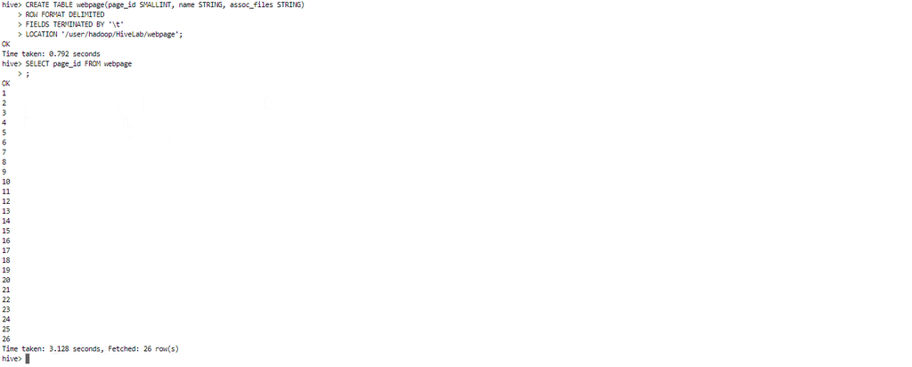

## Task 2: Perform queries against the created table:

In this task, write the queries which:

1- List up the webpages by there names.

2- Get all webpages which their names start by `titanic`

3- Drop the table `webpage`

### 1-list up the webpages by there names

```python
## your queries here and screenshots of results from Hue
## 1- list up the webpages by there names
# SELECT name FROM webpage;
```

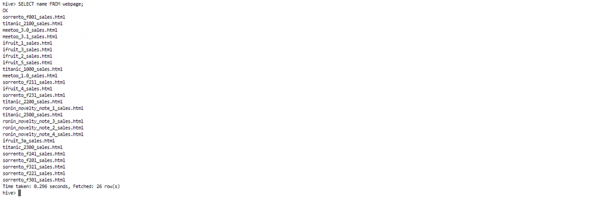

### 2- Get all webpages which their names start by titanic

```python
# SELECT name FROM webpage
#   WHERE NAME LIKE 'titanic%';
```

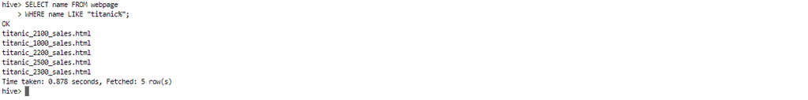

### 3- DROP the table webpage

```python
# DROP TABLE webpage;
```

## Task 3: Data partitioning:

- We will be using the files `from part-m-00000 and part-m-00006` attached with this assignment.
- Put those files into the `hdfs` directory `/user/hadoop/HiveLab/accounts`
- Those files contain customer accounts information of a telecommunication company.

```python
#Run your hdsf commands here
!hdfs dfs -put /home/bitnami/labs/lab3/accounts HiveLab/accounts
```

```python
#check
!sudo hdfs dfs -ls  /user/hadoop/HiveLab/accounts/
```

```
Found 8 items
drwxr-xr-x   - hadoop hadoop          0 2020-12-06 16:33 /user/hadoop/HiveLab/accounts/.ipynb_checkpoints
-rw-r--r--   1 hadoop hadoop    4706617 2020-12-06 16:33 /user/hadoop/HiveLab/accounts/part-m-00000
-rw-r--r--   1 hadoop hadoop    4693530 2020-12-06 16:33 /user/hadoop/HiveLab/accounts/part-m-00001
-rw-r--r--   1 hadoop hadoop    4674529 2020-12-06 16:33 /user/hadoop/HiveLab/accounts/part-m-00002
-rw-r--r--   1 hadoop hadoop    4662646 2020-12-06 16:33 /user/hadoop/HiveLab/accounts/part-m-00003
-rw-r--r--   1 hadoop hadoop        129 2020-12-06 16:33 /user/hadoop/HiveLab/accounts/part-m-00004
-rw-r--r--   1 hadoop hadoop        131 2020-12-06 16:33 /user/hadoop/HiveLab/accounts/part-m-00005
-rw-r--r--   1 hadoop hadoop        131 2020-12-06 16:33 /user/hadoop/HiveLab/accounts/part-m-00006
```

```python
"""
CREATE TABLE accounts
(
cust_id INT,
creationDate STRING,
expirationDate STRING,
fname STRING,
lname STRING,
address STRING,
city STRING,
state STRING,
zipcode STRING
)
ROW FORMAT DELIMITED
FIELDS TERMINATED BY ','
LOCATION '/user/hadoop/HiveLab/accounts'
"""
```

```
"CREATE TABLE accounts\n(\ncust_id INT,\ncreationDate STRING,\nexpirationDate STRING,\nfname STRING,\nlname STRING,\naddress STRING,\ncity STRING,\nstate STRING,\nzipcode STRING\n)\nROW FORMAT DELIMITED \nFIELDS TERMINATED BY ','\nLOCATION '/user/hadoop/HiveLab/accounts'"
```

You can use the schema below

```
(
cust_id INT,
creationdate STRING,
expirationDate STRING,
fname STRING,
lname STRING,
address STRING,
city STRING,
state STRING,
zipcode STRING
)
```

- Create partitioned table accounts_by_State

  ```
  CREATE Table accounts_by_State(
  cust_id INT,
  fname STRING,
  lname STRING,
  address STRING,
  city STRING,
  zipcode STRING
  )
  PARTITIONED BY (state STRING);
  ```

- From `Hive Shell` or from `Hue Query Editor` run the following commands that will enable dynamic partitioning:

  ```
  SET  hive.exec.dynamic.partition = true;
  SET  hive.exec.dynamic.partition.mode = nonstrict;
  SET hive.exec.max.dynamic.partitions.pernode=400;
  ```

- Load data into `accounts_by_State` and dynamically create partitions by `state`

  ```
  INSERT OVERWRITE TABLE accounts_by_State
  PARTITION(state)
  SELECT cust_id, fname, lname,address, city, zipcode, state
  FROM accounts;
  ```

- Now the get the first name and the last name of all customers from "NV" state.
  - perform this query on both tables
  - Share your observations.

```python
##put your queries and observations here.
# It is supposed to be faster in case of partitioing because it won't go through
#all files created while quering a certain state, It is partitioned by state, so
#it will only go through th file with the state name and query the information
#I want to gain
```

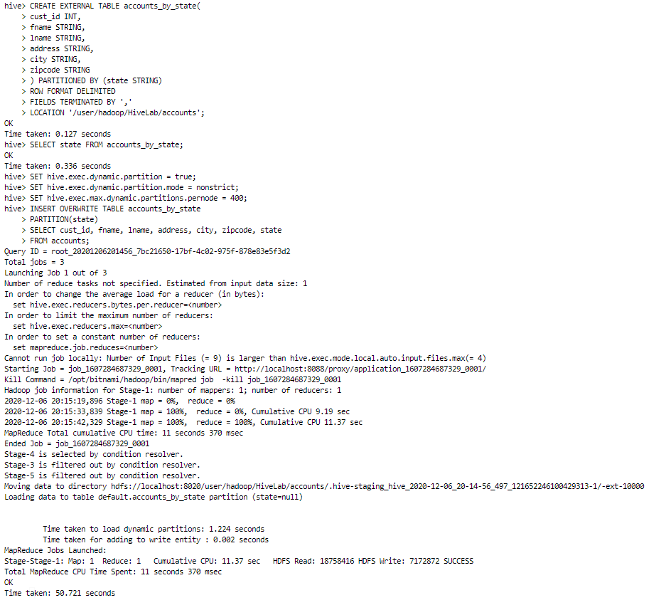

```python
#SELECT fname, lname FROM accounts WHERE state = 'NV';
```

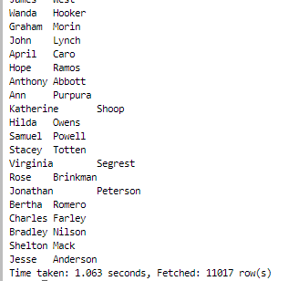

```python
##put your queries and observations here.
#CREATE EXTERNAL TABLE accounts_by_state(
#cust_id INT,
#fname STRING,
#lname STRING,
#address STRING,
#zipcode STRING)
#PARTITIONED BY(state STRING)
#ROW FORMAT DELIMITED
#FIELDS TERMINATED BY ','
#LOCATION '/user/hadoop/HiveLab/accounts_by_state';

#INSERT OVERWRITE TABLE accounts_by_sate
#PARTITION(state, city)
#SELECT cust_id, fname, lname, address, zipcode, state, city
#FROM accounts;
```

[figure not shown]

```python
#SELECT fname, lname FROM accounts_by_state WHERE state = 'NV';
```

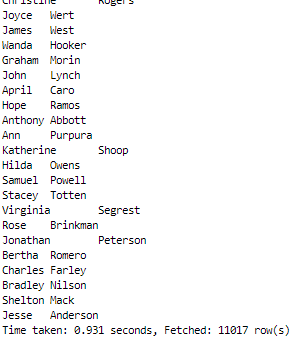

#### It might be tricky in this small dataset but in a real life scenario while dealing with big data, in case of accounts_by_state it will only access the files which is partitioned by state = 'NV' and won't need to iterate over the whole dataset to find the required query same case in accounts_by_state_city it will deal only with the files in the query written, so it should be even faster

- Create partitioned table accounts_by_State_city

```
CREATE Table accounts_by_State_City(
cust_id INT,
fname STRING,
lname STRING,
address STRING,
zipcode STRING
)
PARTITIONED BY (state STRING, city STRING)
```

- insert

```
INSERT OVERWRITE TABLE accounts_by_State_City
PARTITION(state,city)
SELECT cust_id, fname, lname,address, zipcode, state, city
FROM accounts;
```

```python
#SELECT fname, lname FROM accounts_by_state_city WHERE city = 'NV';
```

[figure not shown]

[figure not shown]

```python
## put your queries and screenshots here
```

```python
set hive.exec.mode.local.auto.input.files.max=10
```

## Task 4: Data Bucketing

We will now need to practice bucketing of the data.

- We have to create a bucketed table called `accounts_in_buckets`. We shall bucket on the `state` field(2 buckets)
- We have to run an *insert from select* statement to load the data from the original `accounts` table into the new accounts_in_buckets table.
- Finally, we run the same queries from task 3 on the bucketed (clustered) table

```python
#SET hive.enforce.bucketing = true,
## If we don't enforce dynamic bucketing as above, we have to add extra properties to the command
## set mapred.reduce.tasks=<NO_OF_BUCKETS> 2 in our case
```

[figure not shown]

```python
#DESCRIBE FORMATTED accounts_in_buckets
```

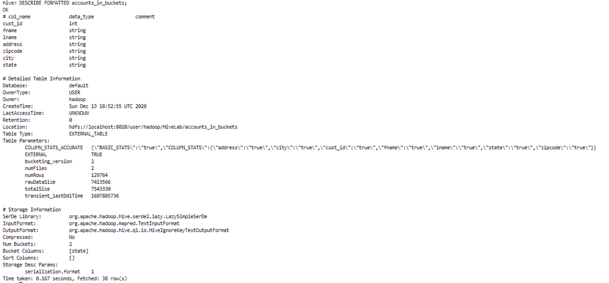

```python
#SELECT fname, lname FROM accounts_in_buckets WHERE state = 'NV';
```

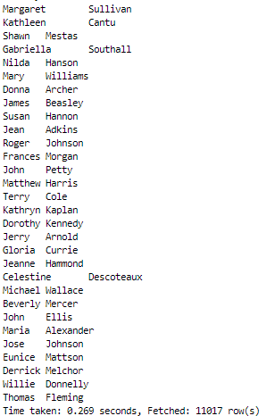

```python
#put your queries and screenshots here
```

## Task 5: Change Storage Formats

We will use Hive to transform data formats from textual into other binary formats. We can transform the original `accounts` table into AVRO once and into Parquet another time.

- create table `accounts_avro` and instruct Hive to store it as AVRO
- Similarly, create table `accounts_parquet`
- Load the data from the original table `accounts` into the target tables via *insert from select* statements
- Finally, run the same queries from Task 3 to make sure that everything works fine.

# Using the following schema

```
('avro.schema.literal'='{
  "type" : "record",
  "name" : "Accounts",
  "doc" : "Schema for the accounts_avro table",
  "fields" : [ {
    "name" : "cust_id",
    "type" : [ "int", "null" ]
  }, {
    "name" : "fname",
    "type" : [ "string", "null" ]
  }, {
    "name" : "lname",
    "type" : [ "string", "null" ]
  }, {
    "name" : "address",
    "type" : [ "string", "null" ]
  }, {
    "name" : "city",
    "type" : [ "string", "null" ]
  }, {
    "name" : "zipcode",
    "type" : [ "string", "null" ]
  }, {
    "name" : "state",
    "type" : [ "string", "null" ]
  } ]
}')
```

```python
#Put the screenshot here and your statement
CREATE EXTERNAL TABLE accounts_avro(
cust_id INT,
fname STRING,
lname STRING,
address STRING,
zipcode STRING,
city STRING,
state STRING)
STORED AS Avro
LOCATION '/user/hadoop/HiveLab/accounts_avro';

INSERT OVERWRITE TABLE accounts_avro
SELECT cust_id, fname, lname, address, zipcode, city, state FROM accounts;
```

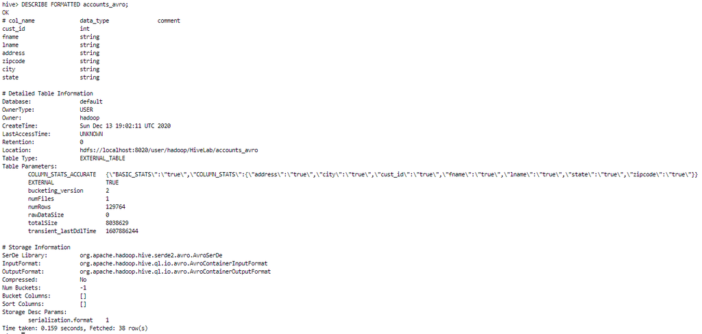

```python
SELECT * FROM accounts_avro;
```

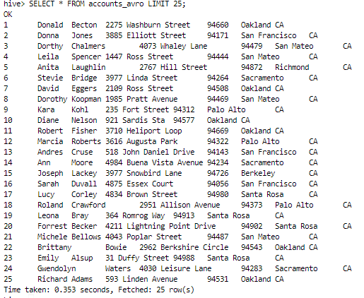

```python
## Create the table as Parquet
```

```python
#Put the screenshot here and your statement
"""
CREATE EXTERNAL TABLE accounts_parquet(
cust_id INT,
fname STRING,
lname STRING,
address STRING,
zipcode STRING,
city STRING,
state STRING)
STORED AS parquet
LOCATION '/user/hadoop/HiveLab/accounts_parquet';

INSERT OVERWRITE TABLE accounts_parquet
SELECT cust_id, fname, lname, address, zipcode, city, state FROM accounts;
"""
```

[output not shown]

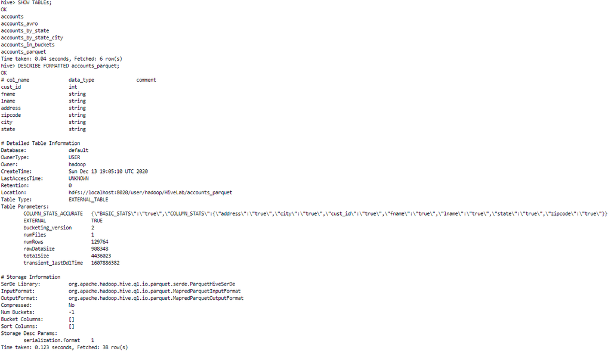

```python
##INsert sataements and check by screenshots

#SELECT * FROM accounts_parquet LIMIT 25;
```

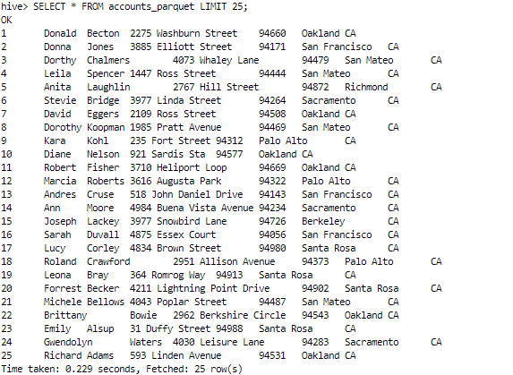